MOD510 22H| Mandatory Project 4| Coronavirus Goes Randomly Viral

Andreas Nonslid Håvardsen | Daniel Fylling | Sahar Kadkhodamasoum Ali

# Abstract

Spreading of viruses through populated areas has been identified as a major concern of spatial epidemology. In order to analyze the spatial and temporal distribution of infectious diseases in a given population with different geographical settings, we need to build dynamic models that predict outbreak behavoiur globally. Transmission of an infectious disease may occur through several pathways;

1. By means of contact with infected individuals
2. By water, airbone inhalation
3. Through vector-borne spread (1).

However, this project focuses on direct contact with an infected individual as the main method of contagious disease transmission. The goal of this project is modeling the dynamics of epidemics based on a Random Walk Model (RWM). In each exercise we model different flows of people from one compartment to another one. In addition, RWS models is going to be compared with the Classical Compartment Model which is used in Ordinary Differential Equation to figure out how epidemic dynamics spread out in the population. We found that assuming the disease transmission rate ($\beta$) to be constant, wasn't sufficient to represent the real world.

Throughout this exercise we also observe that the model behaves like a Sigmoid function (5), when it only has infected and susceptible people, whereas we see a skewed normal distribution (6) when adding a big recovery rate.

# Introduction

In this project, we use a very simple model: a random walker simulation (which is modeled on an infected person) takes a positive integer number of steps on a 2D square lattice. In each step, the visited site has a probability p of becoming infected. In this case, at the site of the new infection, it branches off another random walker, also with lifetime τ, that can also further spread the contagion to further sites, and so on. Our goal is studying the results from two aspects of temporal and spatial. During this project, it is proved that increasing the number of initial infected persion leads to an decrease in number of time steps for all people being infected.

In this project we use a random walker simulation to simulate the spread of a virus through a population.

The way this works is by using a 2-dimensional grid for positions. Then the population occupy this grid, sharing the disease by having a already infected person and susceptible person step on the same square. When they do, a random chance check decides whether it spread to this person or not.

## Excercise 1: Random walk simulation with SI-model

At first, we consider the RWS in the simplest condition which is SI-model (Susceptible-Infected). In this model, a 2-D rectangular lattice with the cordinations of 50*50 is the restricted spatial area. In each time step, people can moved randomly between neighbouring nodes by moving North, South, East and West. Then, the state of people after each time step is defined between terms: Susceptible and infectiuos. Susceptible people has the probability of 0.9 for getting infected (3).

### Part 1

In this part, we coded a class **(RandomlyViral)** for RWS.

```python
import matplotlib.pyplot as plt
import numpy as np
from scipy.integrate import odeint
import pandas as pd
import seaborn as sns
import math
import os
from randomlyViral import RandomlyViral
```

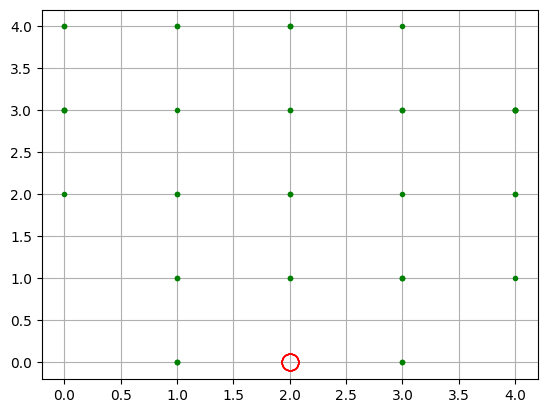

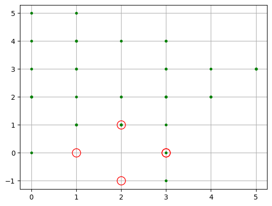

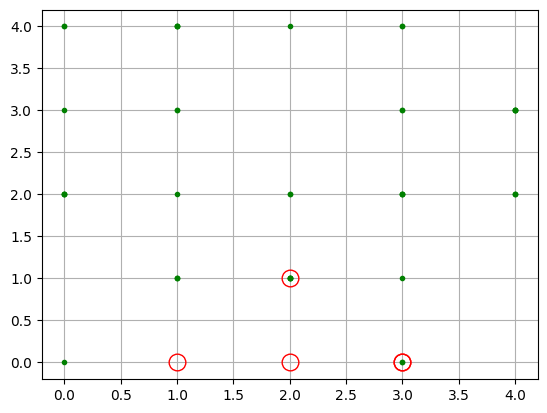

```python
RandomlyViral(simulation_size = 'small' ,no_init_infected=1).single_simulation()
```

**Plot 1 - t=0**  
In this plot, there are 50 randomly placed "Walkers", of which one is infected (red circle) all the others are susceptible in a 5x5 grid is shown. We observe that the infectious walkers is seemingly by itself, but this is not neccessarily the case. That is because the walkers first infect (with some probability) those in their own grid cell, before moving. In this plot therefore, the walkers have not yet had the time to move, and might just be many infected people stacked on top of eachother.

**Plot 2 - t=1**  
*After running movement function, we can see that the infectious walkers have spread and that some walkers have left the "legal" 5x5 grid area.* This is not a real timestep since no data is recorded in this state.*

**Plot 3 - t=1**  
After reverting the illegal moves, we can see that all walkers are back in the designated grid.

*Escape is not possible.*

### Part 2

In this part, the number of initially infectious individuals is set to be 1. Then the model is run 100 times and each run consists of 300 time steps. After all the runs is done, the mean and standard deviation of these for both susceptible and infectious people are calculated. Dotted lines represent mean values and colored area represents plus/minus one standard deviation.

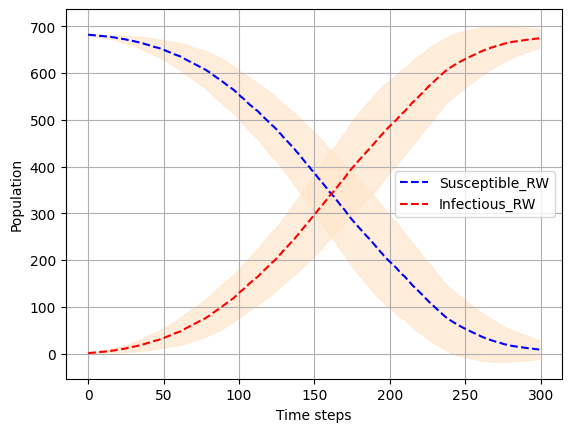

```python
RandomlyViral(no_init_infected=1).plot_simulation()
```

### Part 3

In this part, the number of initially infectious individuals is set to be 10, and run it again. The reason why there is no parameters in the call is because 10 is the default number of initially infected.

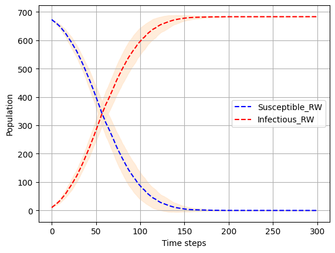

```python
RandomlyViral().plot_simulation()
```

Observations:

- Spread is a lot quicker when starting with 10 infected individuals, and standard deviation is less. Both make intuitive sense - a quicker and less random initial spread when starting off with more infected.
- On closer inspection we can see that the spread when startin with 10 infected is a lot faster than for one. Time taken from I=10 to I~=675 (almost full infection) is here about 150 time steps. In the first case, from I=1 to I~=675, the process took about 300 steps. In the first case, from I=1 to I~=10, took approximately 30 days. This means that in the first scenario the time from I=10 to I~=675 is about 270, still almost double of second case. It seems reasonable to think that this difference is related to the fact that in the second case the initial 10 infected walkers are all randomly placed on the grid. In the first case, after reaching I=10, all infected walkers are still relatively close together, and don't interact with as many susceptible people as if they had been spread around the grid.

*In our modern society with plenty of fast modes of travel, individuals are not limited to only moving at a constant rate.*